# **ANALIZA EKSPLORACYJNA DANYCH** (EDA-TITANIC)

- **Wprowadenie**

Zbiór danych zawiera informacje o pasażerach RMS Titanic, który zatonął 15 kwietnia 1912 roku po zderzeniu z górą lodową. Dane obejmują takie atrybuty jak klasa podróży, wiek, płeć, liczba rodzeństwa/małżonków na pokładzie, liczba rodziców/dzieci na pokładzie, cena biletu oraz miejsce zaokrętowania.

Zbiór zawiera także informację o tym, czy pasażer przeżył katastrofę.

Titanic przewoził ponad 2,200 osób, z czego ponad 1,500 zginęło, co czyni tę katastrofę jedną z najbardziej tragicznych w historii morskiej.

Kolumny:

- **pclass** - Klasa biletu
- **survived** - Czy pasażer przeżył katastrofę
- **name** - Imię i nazwisko pasażera
- **sex** - Płeć pasażera
- **age** - Wiek pasażera
- **sibsp** - Liczba rodzeństwa/małżonków na pokładzie
- **parch** - Liczba rodziców/dzieci na pokładzie
- **ticket** - Numer biletu
- **fare** - Cena biletu
- **cabin** - Numer kabiny
- **embarked** - Port, w którym pasażer wszedł na pokład (C = Cherbourg, Q = Queenstown, S = Southampton)
- **boat** - Numer łodzi ratunkowej
- **body** - Numer ciała (jeśli pasażer nie przeżył i ciało zostało odnalezione)
- **home.dest** - Miejsce docelowe

[figure not shown]

# Titanic - prawdziwa historia...

```
Jest godzina 23:40, 14 kwietnia 1912 roku. W bocianim gnieździe zawieszonym 20 metrów nad pokładem marynarze Frederick Fleet i Reginald Lee dostrzegają przed dziobem oddaloną około 400-450 metrów czarna masę. Góra lodowa wydaje się niewielka lecz szybko ogromnieje. Fleet trzy krotnie uderza w dzwon alarmowy. "Góra lodowa na wprost!!!" - krzyczy w słuchawkę telefonu. Pierwszy oficer William Murdoch natychmiast nakazuje dać ster ostro na bakburtę, a do maszynowni wrzeszczy: "Cała wstecz!!!". Titanic zbliża się do góry lodowej z prędkością sprintera - 11,5 metra na sekundę. Dziób stalowego kolosa o wiele za wolno odchyla się od kursu i niestety następuje zderzenie. Mniejsze i większe kawały lodu z hukiem spadają na przedni pokład, na czwartym piętrze statku.
Odłamki lodu spadają na pokład Titanica. Okazuje się, że pasażerowie którzy wyszli na pokład zobaczyć, co się stało beztrosko zaczynają bawić się kawałkami lodu. Ktoś na pokładzie zaczyna kopać bryłę lodu dla żartu, ktoś inny bierze kawałek i używa go do schłodzenia whisky. Nikt nie przypuszcza, że Titanic może zatonąć, to przecież statek niezatapialny. Minęły ledwie dwie minuty od zderzenia. Nikt niczego nie podejrzewa...

W momencie kolizji jedynie palacze w najbardziej wysuniętej ku dziobowi kotłowni usłyszeli piekielny hałas, a zielonkawa, spieniona i lodowata woda Atlantyku zaczęła zalewać ich grubymi strugami. Jednak na górnym pokładzie pierwszej klasy tylko leciutko drżą szkła, jakby anioł przeszedł przez salon. Czterej stewardzi samotnie spożywający późną kolację w jadalni pierwszej klasy ze zdziwieniem stwierdzają, że oto brzęczą przygotowane już do śniadania srebrne sztućce. Na mostek wpada zaalarmowany wstrząsem kapitan Edward J. Smith. "Zamknąć grodzie!" - woła, "Już wykonane!" - odpowiada pierwszy oficer.
Na Titanicu zapada grobowa cisza. Kapitan oraz konstruktor statku Thomas Andrews próbują sprawdzić, jak duże są uszkodzenia statku. Smith schodzi na sam dół liniowca w towarzystwie Andrewsa, dyrektora technicznego stoczni Harland and Wolff w Belfaście, w której zbudowano ten jak dotąd największy na świecie statek. Wracają 3 minuty po północy i Andrews wypowiada wyrok śmierci: "Titanic musi pójść na dno". Wyrwy w kadłubie ciągną się na długości 6 na ogółem 16 przedziałów wodoszczelnych, a statek może wytrzymać zalanie co najwyżej czterech. "Przecież nie może tak po prostu zatonąć?!" - pyta zrozpaczony kapitan. "Pozostało nam najwyżej półtorej godziny" - odpowiada zimno konstruktor.

Dopiero w godzinę po zderzeniu z górą lodową marynarze biorą się do klarowania szalup. Jest ich jednak zbyt mało, w dodatku przybyli zbyt późno i nie działają sprawnie. Pochodzą z różnych jednostek, nie stanowią zespołu, a czas nagli. Jest 45 minut po północy, w kalendarzu już 15 kwietnia. Pierwsze sygnały od Titanica idą w świat - jest bardzo niedobrze.

W niebo wzlatuje pierwsza wystrzelona raca, która rozświetla przedni pokład i mnóstwo pobladłych twarzy. Teraz już wszyscy zrozumieli, że śmierć jest blisko. Kolorowe race mają zwrócić uwagę statku Californian, którego światła pozycyjne widać z pokładu Titanica. Oficer wachtowy Californiana rzeczywiście dostrzega rakiety, jednak nie domyśla się co one mogą oznaczać. Zaalarmowany kapitan Stanley Lord nie wpada na pomysł, aby uruchomić maszyny i włączyć radiostację. Woli spać snem sprawiedliwego. Tak właśnie zaprzepaszczona została ostatnia szansa uratowania ludzi z tonącego Titanica. Na próżno drugi oficer śmiertelnie rannego giganta Charls Lightoller wścieka się: "Dałbym wszystko za piętnastocentymetrowe działo i kilka granatów, aby obudzić tych facetów".

Na pokładzie Titanica jest ponad 2200 osób, dla ponad 700 z nich zwyczajnie nie ma miejsca. Przygotowane do opuszczenia są już pierwsze szalupy, ale ludzie w ogóle nie chcą do nich wchodzić, nikt nie wierzy, że Titanic zatonie. Ktoś zawołał głośno: "Słuchajcie, Titanic jest niezatapialną szalupą, więc nie ma sensu do nich wchodzić. Woda jest przecież bardzo zimna". Na dworze panuje przenikliwy chłód, nikt nie chce wychodzić na pokład. O godzinie 00:15, orkiestra przenosi się z salonu na pokład statku, aby zachęcić ludzi do wyjścia, do wsiadania do szalup. Zaczyna grać i będzie grała na pokładzie do samego końca, do ostatnich chwil statku. Pół godziny później zostaje spuszczona pierwsza szalupa, w której znajduje się zaledwie 28 osób, choć może ona pomieścić nawet 70 ludzi. Zaś godzinę później ok. 01:30, zaczyna pojawiać się pierwsza panika wśród pasażerów. Stewardzi zostają wyposażeni w broń, dlatego że niektórzy na siłę próbują dostać się do szalup. Pierwszeństwo mają kobiety i dzieci. Niektórzy dżentelmeni przebierają się w smokingi i we fraki, chcą godnie umrzeć, jak sami mówią. Na statku mają miejsce rozdzierające sceny.

Sytuacja na tonącym Titanicu jest coraz bardziej dramatyczna. W niespełna dwie godziny po kolizji z górą lodową, przechylenie statku jest coraz większe. Co robi kapitan i główny konstruktor? Światła okrętu czerwienieją i migocą, kapitan Smith ostatni raz zagląda do radiotelegrafistów: "Spełniliście swój obowiązek, a teraz ratuj się kto może" - nakazuje, po czym udaje się na mostek. Od tej pory nikt go już więcej nie widział. Thomas Andrews, konstruktor statku stoi z założonymi rękami w salonie palarni. Jego kamizelka ratunkowa leży niedbale przerzucona przez stół. Andrews już zdecydował. Nie będzie się ratować. Chce pójść na dno razem ze swoim statkiem.

   W dwie godziny i 40 minut po kolizji, rufa statku odchyla się od kadłuba i w następstwie następuje przełamuje się statku na dwie części, pod kątem ok. 70 stopni. Wiele przedmiotów wypada z zewnątrz. Niektóre z nich są bardzo ciężkie, jak np. sejf, a niektóre całkiem lekkie jak: krzesła, buty. Stalowy 'sarkofag' z rosnącą szybkością zapada w morską toń. Rufa podskakuje jeszcze jak korek, po czym po prostu zsuwa się w otchłań oceanu. Ostatni ludzie spadają i uderzają z hukiem o powierzchnię wody, albo zostają zmieceni z pokładu, gdy Atlantyk w zadziwiającej ciszy połyka swoją ofiarę. Nie ma ani śladu wirów czy kipieli, pozostaje tylko chmura dymu lub mgły w kształcie grzyba. Statek idzie na dno w całkowitej ciszy. Na powierzchni przez 2 minuty panuje osobliwe milczenie. Jak opowiadali później naoczni świadkowie ocean był tej nocy zupełnie spokojny, wody była gładka jak lustro. Teraz nie ma niczego, nie ma żadnego odgłosu, jest cisza. Nagle z gardeł setek ludzi, którzy jeszcze żywi pływają w wodzie, wydziera się wielki okrzyk rozpaczy.

Na szczególną uwagę oraz podziw zasługują starania członków załogi Titanica. To właśnie nim zawdzięcza się starania, aby statek do końca był oświetlony. Za tą heroiczną walkę życiem przypłaciło parunastu marynarzy, którzy siedzieli w pokładowej elektrowni i podtrzymywali dostawę prądu, aby na pokładzie nie wybuchła dodatkowa panika, gdyby nagle zgasło światło.

Najgorszy los spotkał około 500 pasażerów, uwięzionych gdzieś wewnątrz statku. Według świadków katastrofy, podobno był taki dramatyczny moment, kiedy marynarze zdecydowali się zamknąć cały pokład dla pasażerów trzeciej klasy, aby uniknąć zbyt dużej masy ludzi na pokładzie zewnętrznym. Zdawano sobie przy tym sprawę, iż wypuszczenie tych ludzi nic nie zmieni, ponieważ z pokładu tonącego Titanica spuszczano już ostatnie szalupy, w których nie było wolnych miejsc.
Na powierzchni pływają łodzie ratunkowe, niektóre z nich puste do połowy i ok. 500 ludzi w wodzie. Temperatura wody oscyluje w granicach 4 stopni, ze względu na bardzo bliskie położenie pól lodowych. Wśród rozbitków, żarliwie walczących o życie w lodowatej wodzie panuje straszliwy, rozpaczliwy krzyk. Ani jedna szalupa nie podpływa. Wszystkie stoją w odległości ok. 200 metrów od rozbitków. Ostatecznie, tylko dwie łodzie pospieszyły na ratunek nieszczęśnikom - szalupa nr 4 wyłowiła 6 lub 7 palaczy i stewardów, dwaj umierają na łodzi, a jeden jest tak pijany, że kilka rezolutnych niewiast musi na nim usiąść, aby go obezwładnić.

Łodzią nr 14, oficer Lowe i czterej ochotnicy ostrożnie podpływają do kłębowiska ginących ludzi, przesadziwszy wcześniej pozostałych pasażerów na inne łodzie. Lowe zatrzymuje szalupę jakieś 150 metrów od umierających i odczekuje godzinę, aż rozbitkowie osłabną. Mogą przecież przewrócić szalupę. Wielu, z tych których chciano wyłowić z wody już nie żyło. Ochotnikom z łodzi nr 14 udało się wyłowić zaledwie 4 ludzi, z których jeden brocząc krwią z nosa i ust niemal od razu umiera.
Ludzie konają w lodowatej wodzie, umierają na hipotermię (z wyziębienia). Najsilniejsi podobno wytrzymali ponad godzinę. Na kilku łodziach trwała dyskusja, podpływać czy nie podpływać, ratować czy nie ratować. Obawiano się tego, że w przypadku zbliżenia się do umierających w lodowatej wodzie, ci mogą odruchowo wywrócić łódź, próbując się ratować. Podejmowane są decyzje, żeby jednak nie płynąć. Na jednej z lodzi rozpoczyna się wręcz śpiewanie religijnych pieśni, aby zagłuszyć potworne wycie, konających z zimna ludzi.
```

# 1. OGÓLNY PRZEGLĄD DANYCH.

- **Zestawienie dostępnych informacji**

|  | pclass | survived | name | sex | age | sibsp | parch | ticket | fare | cabin | embarked | boat | body | home.dest |
| --- | --- | --- | --- | --- | --- | --- | --- | --- | --- | --- | --- | --- | --- | --- |
| 0 | 1.0 | 1.0 | Allen, Miss. Elisabeth Walton | female | 29.0000 | 0.0 | 0.0 | 24160 | 211.3375 | B5 | S | 2 | NaN | St Louis, MO |
| 1 | 1.0 | 1.0 | Allison, Master. Hudson Trevor | male | 0.9167 | 1.0 | 2.0 | 113781 | 151.5500 | C22 C26 | S | 11 | NaN | Montreal, PQ / Chesterville, ON |
| 2 | 1.0 | 0.0 | Allison, Miss. Helen Loraine | female | 2.0000 | 1.0 | 2.0 | 113781 | 151.5500 | C22 C26 | S | NaN | NaN | Montreal, PQ / Chesterville, ON |
| 3 | 1.0 | 0.0 | Allison, Mr. Hudson Joshua Creighton | male | 30.0000 | 1.0 | 2.0 | 113781 | 151.5500 | C22 C26 | S | NaN | 135.0 | Montreal, PQ / Chesterville, ON |
| 4 | 1.0 | 0.0 | Allison, Mrs. Hudson J C (Bessie Waldo Daniels) | female | 25.0000 | 1.0 | 2.0 | 113781 | 151.5500 | C22 C26 | S | NaN | NaN | Montreal, PQ / Chesterville, ON |
| ... | ... | ... | ... | ... | ... | ... | ... | ... | ... | ... | ... | ... | ... | ... |
| 1305 | 3.0 | 0.0 | Zabour, Miss. Thamine | female | NaN | 1.0 | 0.0 | 2665 | 14.4542 | NaN | C | NaN | NaN | NaN |
| 1306 | 3.0 | 0.0 | Zakarian, Mr. Mapriededer | male | 26.5000 | 0.0 | 0.0 | 2656 | 7.2250 | NaN | C | NaN | 304.0 | NaN |
| 1307 | 3.0 | 0.0 | Zakarian, Mr. Ortin | male | 27.0000 | 0.0 | 0.0 | 2670 | 7.2250 | NaN | C | NaN | NaN | NaN |
| 1308 | 3.0 | 0.0 | Zimmerman, Mr. Leo | male | 29.0000 | 0.0 | 0.0 | 315082 | 7.8750 | NaN | S | NaN | NaN | NaN |
| 1309 | NaN | NaN | NaN | NaN | NaN | NaN | NaN | NaN | NaN | NaN | NaN | NaN | NaN | NaN |

1310 rows × 14 columns

|  | pclass | survived | age | sibsp | parch | fare | body |
| --- | --- | --- | --- | --- | --- | --- | --- |
| count | 1309.000000 | 1309.000000 | 1046.000000 | 1309.000000 | 1309.000000 | 1308.000000 | 121.000000 |
| mean | 2.294882 | 0.381971 | 29.881135 | 0.498854 | 0.385027 | 33.295479 | 160.809917 |
| std | 0.837836 | 0.486055 | 14.413500 | 1.041658 | 0.865560 | 51.758668 | 97.696922 |
| min | 1.000000 | 0.000000 | 0.166700 | 0.000000 | 0.000000 | 0.000000 | 1.000000 |
| 25% | 2.000000 | 0.000000 | 21.000000 | 0.000000 | 0.000000 | 7.895800 | 72.000000 |
| 50% | 3.000000 | 0.000000 | 28.000000 | 0.000000 | 0.000000 | 14.454200 | 155.000000 |
| 75% | 3.000000 | 1.000000 | 39.000000 | 1.000000 | 0.000000 | 31.275000 | 256.000000 |
| max | 3.000000 | 1.000000 | 80.000000 | 8.000000 | 9.000000 | 512.329200 | 328.000000 |

|  | pclass | survived | age | sibsp | parch | fare | body |
| --- | --- | --- | --- | --- | --- | --- | --- |
| 0 | 1.000000 | 1.000000 | 29.000000 | 0.000000 | 0.000000 | 211.337500 | nan |

Średnia wieku uczestnika wyprawy to blisko 30 lat

```
29.8811345124283
```

Na pokładzie ludzie byli przyporządkowani do 3 klas. Klasa 1: 323 osoby, klasa 2: 277, Klasa 3: 709 osób

|  | pclass | name |
| --- | --- | --- |
| 0 | 1.0 | 323 |
| 1 | 2.0 | 277 |
| 2 | 3.0 | 709 |

```
Liczba unikalnych wartości w każdej kolumnie:
pclass          3
survived        2
name         1307
sex             2
age            98
sibsp           7
parch           8
ticket        929
fare          281
cabin         186
embarked        3
boat           27
body          121
home.dest     369
dtype: int64
```

# 2. ANALIZA BRAKUJĄCYCH WARTOŚCI.

- **Weryfikacja jakości danych wejściowych**

```
<class 'pandas.core.frame.DataFrame'>
RangeIndex: 1310 entries, 0 to 1309
Data columns (total 14 columns):
 #   Column     Non-Null Count  Dtype
---  ------     --------------  -----
 0   pclass     1309 non-null   float64
 1   survived   1309 non-null   float64
 2   name       1309 non-null   object
 3   sex        1309 non-null   object
 4   age        1046 non-null   float64
 5   sibsp      1309 non-null   float64
 6   parch      1309 non-null   float64
 7   ticket     1309 non-null   object
 8   fare       1308 non-null   float64
 9   cabin      295 non-null    object
 10  embarked   1307 non-null   object
 11  boat       486 non-null    object
 12  body       121 non-null    float64
 13  home.dest  745 non-null    object
dtypes: float64(7), object(7)
memory usage: 143.4+ KB
```

```
pclass          1
survived        1
name            1
sex             1
age           264
sibsp           1
parch           1
ticket          1
fare            2
cabin        1015
embarked        3
boat          824
body         1189
home.dest     565
dtype: int64
```

```
pclass            3
survived          2
name            519
sex               2
age              79
sibsp             7
parch             8
ticket          230
fare            157
cabin            84
embarked          3
boat             22
body             38
home.dest       129
relationship      8
dtype: int64
```

```
Liczba brakujących wartości w każdej kolumnie po usunięciu niektórych kolumn:
pclass            1
survived          1
name              1
sex               1
age             264
sibsp             1
parch             1
fare              2
embarked          3
relationship      1
dtype: int64
```

```
Liczba brakujących wartości w każdej kolumnie po uzupełnieniu:
pclass          0
survived        0
name            0
sex             0
age             0
sibsp           0
parch           0
fare            0
embarked        0
relationship    1
dtype: int64
```

# 3. ANALIZA POJEDYŃCZYCH ZMIENNYCH.

- Wykres nr 1. Histogram rozkładu podstawowych informacji

[output not shown]

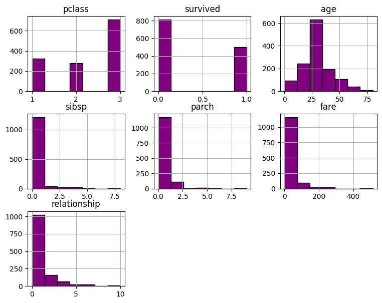

- Wykres nr 2. Histogram podziału pasażerów ze wzgledu na płeć

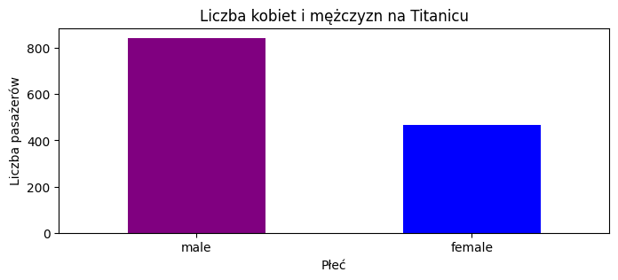

- Wykres nr 3. Histogram portów

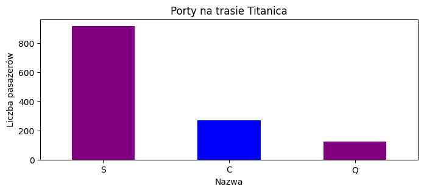

Opis wykresu:

Kod Port: S Southampton (Anglia) C Cherbourg (Francja) Q Queenstown (Irlandia)

- Wykres nr 4. Histogram - grupy wiekowe

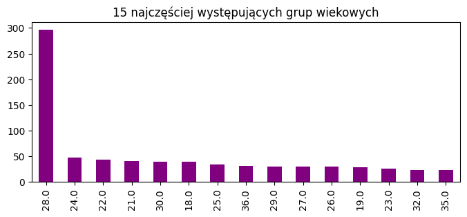

- **Wnioski - Analiza pojedyńczych zmiennych**
- Najwięcej pasażerów wyruszyło w podróż w porcie Southampton, następnie w Cherbourg, a najmniej w Queenstown,
- Najwięcej osób, ponad połowa podróżowało trzecią klasą a najmniej drugą,
- Więcej pasażerów było płci męskiej,
- Większość biletów kosztowała poniżej 50 jednostek walutowych,
- Największa liczba pasażerow byla w wieku młodym do średniej dorosłości, z wyraźnym pikiem około 28 lat,

# 4. ANALIZA WARTOŚCI ODSTAJĄCYCH.

|  | pclass | survived | name | sex | age | sibsp | parch | fare | embarked | relationship |
| --- | --- | --- | --- | --- | --- | --- | --- | --- | --- | --- |
| 0 | 1.0 | 1.0 | Allen, Miss. Elisabeth Walton | female | 29.0000 | 0.0 | 0.0 | 211.3375 | S | 0.0 |
| 1 | 1.0 | 1.0 | Allison, Master. Hudson Trevor | male | 0.9167 | 1.0 | 2.0 | 151.5500 | S | 3.0 |
| 2 | 1.0 | 0.0 | Allison, Miss. Helen Loraine | female | 2.0000 | 1.0 | 2.0 | 151.5500 | S | 3.0 |
| 3 | 1.0 | 0.0 | Allison, Mr. Hudson Joshua Creighton | male | 30.0000 | 1.0 | 2.0 | 151.5500 | S | 3.0 |
| 4 | 1.0 | 0.0 | Allison, Mrs. Hudson J C (Bessie Waldo Daniels) | female | 25.0000 | 1.0 | 2.0 | 151.5500 | S | 3.0 |
| ... | ... | ... | ... | ... | ... | ... | ... | ... | ... | ... |
| 1305 | 3.0 | 0.0 | Zabour, Miss. Thamine | female | 28.0000 | 1.0 | 0.0 | 14.4542 | C | 1.0 |
| 1306 | 3.0 | 0.0 | Zakarian, Mr. Mapriededer | male | 26.5000 | 0.0 | 0.0 | 7.2250 | C | 0.0 |
| 1307 | 3.0 | 0.0 | Zakarian, Mr. Ortin | male | 27.0000 | 0.0 | 0.0 | 7.2250 | C | 0.0 |
| 1308 | 3.0 | 0.0 | Zimmerman, Mr. Leo | male | 29.0000 | 0.0 | 0.0 | 7.8750 | S | 0.0 |
| 1309 | 3.0 | 0.0 | Unknown | male | 28.0000 | 0.0 | 0.0 | 14.4542 | S | NaN |

1310 rows × 10 columns

- Wykres nr 5. Boxplot - wiek podróźujących

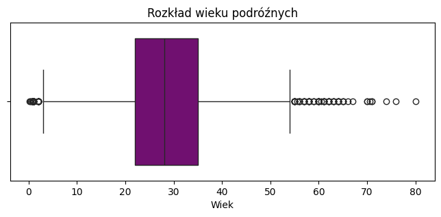

Wykres nr 6. Boxplot - członkowie rodzin

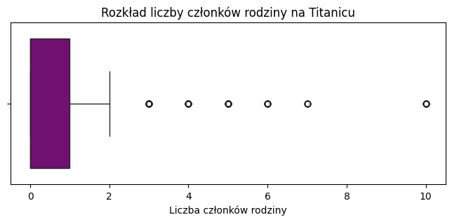

Wykres nr 7. Boxplot - Cena biletu

[figure not shown]

- **Wnioski - Wartości odstające**
- Klasy biletów (pclass) i porty (embarked) mają wartości kategoryczne, które nie wykazują wartości odstających,
- Rzadkie przypadki dużych rodzin podróżujących razem,
- W przypadku zmiennych takich jak wiek (age) i cena biletu (fare) widoczne dane odstające. Połowa pasazerow miala miedzy 20 a 40 lat, nieliczni mieli więcej niz 65 lat. Większość pasażerów podróźowała w pojedynkę,

# 5. ANALIZA RELACJI MIEDZY ZMIENNYMI.

|  | survived | sex | age | pclass | fare | sibsp | parch |
| --- | --- | --- | --- | --- | --- | --- | --- |
| survived | 1.000000 | 0.528903 | -0.043737 | -0.312816 | 0.244563 | -0.027529 | 0.082901 |
| sex | 0.528903 | 1.000000 | -0.053586 | -0.125034 | 0.185839 | 0.109848 | 0.213317 |
| age | -0.043737 | -0.053586 | 1.000000 | -0.377878 | 0.178204 | -0.189912 | -0.125801 |
| pclass | -0.312816 | -0.125034 | -0.377878 | 1.000000 | -0.558738 | 0.060502 | 0.018030 |
| fare | 0.244563 | 0.185839 | 0.178204 | -0.558738 | 1.000000 | 0.160460 | 0.221730 |
| sibsp | -0.027529 | 0.109848 | -0.189912 | 0.060502 | 0.160460 | 1.000000 | 0.373689 |
| parch | 0.082901 | 0.213317 | -0.125801 | 0.018030 | 0.221730 | 0.373689 | 1.000000 |

- **Wnioski - Analiza relacji między zmiennymi**
- Dodatnia korelacja sex (płeć), pokazuje, że kobiety miały większą szansę na przeżycie,
- Wiek nie miał minimalny wpływu na szanse przeżycia,
- Ujemna korelacja klasy pokazuje, że pasażerowie o niższej klasie mieli mniejszą szansę na przeżycie,
- Pasażerowie z droższym biletem mieli trochę większe szanse na przeżycie,
- Liczba członków rodziny na pokładzie nie miało większego znaczenia na przeżycie katastrofy.

## Konkluzje

- Już na początkowym etapie analizy można stwierdzić, że większość pasażerów była mężczyznami, wsiadła na statek w porcie Southampton, podróżowała 3 klasą, nie przeżyła katastrofy, była w wieku około 22-35 lat, podróżowała samotnie lub z jednym członkiem rodziny, a za bilet zaplaciła około 7-32 jednostek walutowych.
- Wiemy, ze w rejsie wzielo udzial ponad 2200 pasazerow, natomiast dane mamy tylko dla lekko ponad polowy, 1310

- Analiza danych pasażerów Titanica ujawniła, że płeć, klasa biletu i cena biletu były najważniejszymi czynnikami wpływającymi na przeżywalność - kluczowa dla ocalenia była klasa jaką osoba podrózowała i płeć.
- **Ciekawostki**
- Kiedy zmarła ostatnia osoba z Titanica?

Millvina Dean, a tak naprawdę Elizabeth Gladys, miała kilka tygodni, kiedy wyruszyła z rodziną w podróż Titanikiem. Była jedną z nielicznych osób, które przeżyły tragiczny finał rejsu. I przez długi czas ostatnią ocalałą osobą z katastrofy. Zmarła 31 maja 2009 r.

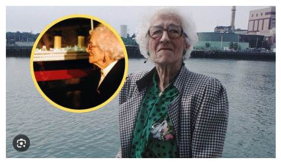

- Ile ciał wydobyto z Titanica?

Z wraku Titanica, spoczywającego na głębokości około 3800 metrów na dnie Atlantyku, nie wydobyto żadnych ciał, ponieważ procesy naturalne sprawiły, że po ponad stu latach nie zachowały się żadne szczątki ludzkie.

- Kto był najbogatszym pasażerem Titanica?

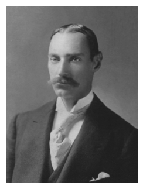

- Czy naszyjnik z Titanica był prawdziwy?

Cóż, filmowa wersja klejnotu tak naprawdę... Nigdy nie istniała. Jest jednak duże podobieństwo jego historii do losów diamentu, zwanego Hope. Była to biżuteria, należąca do Ludwika XIV – nosił owy klejnot, jako naszyjnik królewski.

[output not shown]